# Marketing Analytics

Chapter 5 · Learning from Observational Data

Nils Wlömert

Vienna University of Economics and Business (WU)

November 2026

# Part 1 · Observational data I

## Before we start

**Paper quiz on Chapter 4** *(10 min)*

- Individual, closed book, counts toward participation
- Afterwards: a few leftovers from Chapter 4 and a look at the quiz questions

**Assignment 2** is running: deadline Group A Sun, Nov 8 · Group B Wed, Nov 11; debrief at the start of next session.

**Devices only when we code**

- **Input blocks:** laptops closed, phones away
- **Coding block** (40 min, at the end): laptops open, alone or with your neighbor; results via Menti, then two tables present

Today: correlation and the regression line → reading a regression → adjustment and exogeneity → categorical predictors → prediction vs. explanation → **one coding block with two cases** at the end.

## Today’s session

**Observational data I** *(today)*

5.1 Smart Mix without randomization  
5.2 Correlation, the line, and least squares  
5.3 Reading a regression  
5.4 Adjusting for confounders — and exogeneity  
5.5 Categorical predictors  
5.6 Prediction vs. explanation

**Observational data II** *(next session)*

5.7 Functional form and elasticities  
5.8 Logistic regression  
5.9 Diagnostics that change decisions  
5.10 Difference-in-differences

**Driving question:** *What if we cannot randomize?*

# 5.1 Smart Mix without randomization

## A different history

- Chapter 4: A/B test, 400 users → **+3.2 hours**
- Now: no experiment. Smart Mix launched as an **opt-in** feature
- Four weeks later: data of **2,000 users**, 653 adopters

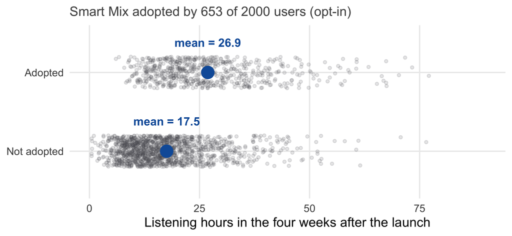

The dashboard says: adopters listen **9.3 hours more** — three times the experimental effect. Would you report this number to management?

## Adopters were different before Smart Mix existed

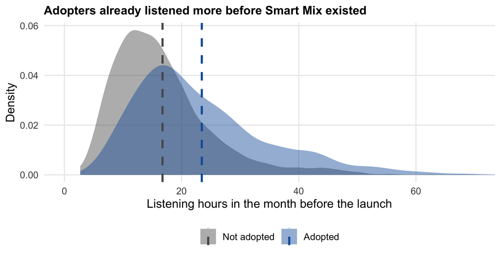

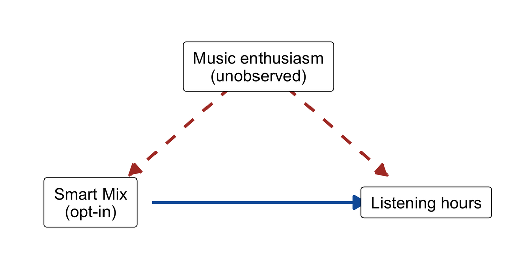

Same costume, new villain: **music enthusiasm** drives adoption *and* listening. Without a coin flip, we have one tool left: **adjustment**.

# 5.2 From correlation to a line

## The correlation coefficient

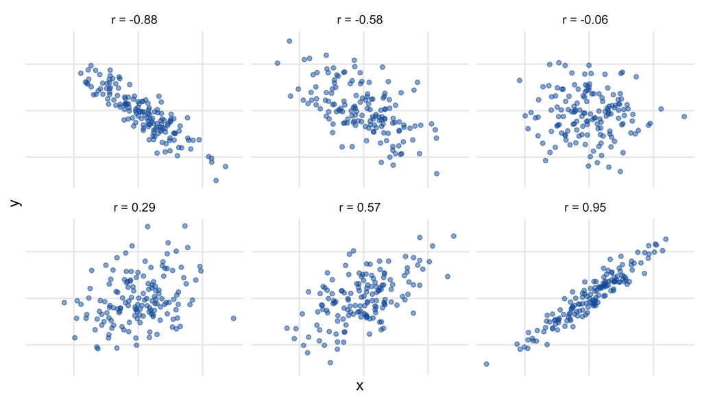

$$r = \frac{\sum_i (x_i - \bar{x})(y_i - \bar{y})}{\sqrt{\sum_i (x_i - \bar{x})^2}\sqrt{\sum_i (y_i - \bar{y})^2}}$$

- Standardized covariance → always between **−1 and +1**, no units
- **Sign** = direction · **size** = how tightly the cloud hugs a straight line
- Rules of thumb: 0.1 small · 0.3 medium · 0.5 large
- Smart Mix: `cor(prior_hours, hours)` = **0.64**

Two caveats: *r* measures **linear** association only (a U-shape can have *r* ≈ 0) — and it is **symmetric**: nothing about which variable causes which.

## Correlation vs. regression

|  | Correlation | Regression |
| --- | --- | --- |
| **Estimated coefficient** | r, bounded between −1 and +1, no units | β₁, a priori not bounded, in units of y per unit of x |
| **Interpretation** | Linear association between two variables; **bidirectional** (r of x and y = r of y and x) | (Linear) relation of one or more predictors to an outcome; **directional** (x explains y) |
| **Role of theory** | Neither required nor testable | Required (which variable is the outcome, which predictors belong in the model) — and testable |

Correlation: *that* and *how tightly* two variables move together. Regression: *how much* y changes with x — which presupposes a direction, and that is where theory and this chapter’s assumptions come in.

## Two variables, one line

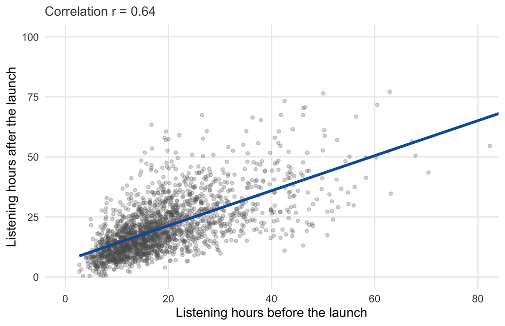

$$\text{hours}_i = \beta_0 + \beta_1 \, \text{prior hours}_i + \varepsilon_i$$

- $i$ = one user · $\beta_0$ **intercept** · $\beta_1$ **slope** · $\varepsilon_i$ **error term**
- Correlation: *that* they move together · regression: *how much*

```r
coef(lm(hours ~ prior_hours, data = smartmix_obs))
```

```
(Intercept) prior_hours
     6.7849      0.7291
```

Each extra hour before the launch **goes with** 0.73 hours after it — *goes with*, not *causes*.

## Which line? Least squares

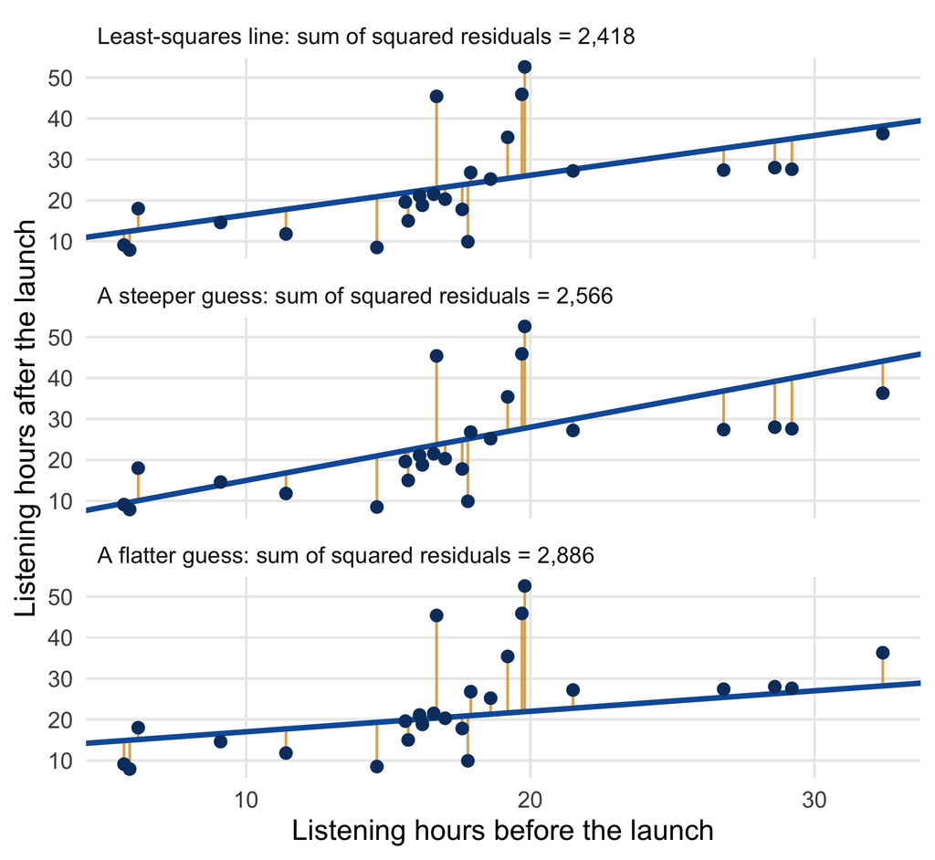

- Residual = observed − predicted (orange segments)
- **OLS** = the line that **minimizes the sum of squared residuals**:

$$\min_{\hat{\beta}_0, \hat{\beta}_1} \sum_{i=1}^{n} \left( y_i - \hat{\beta}_0 - \hat{\beta}_1 x_i \right)^2$$

- Squaring: big misses count a lot; above and below alike · `lm()` does exactly this

**Live demo:** fit the line yourself — course book, §5.2

https://wu-rds.github.io/MA2026/05-observational-data.html#sec-obs-line

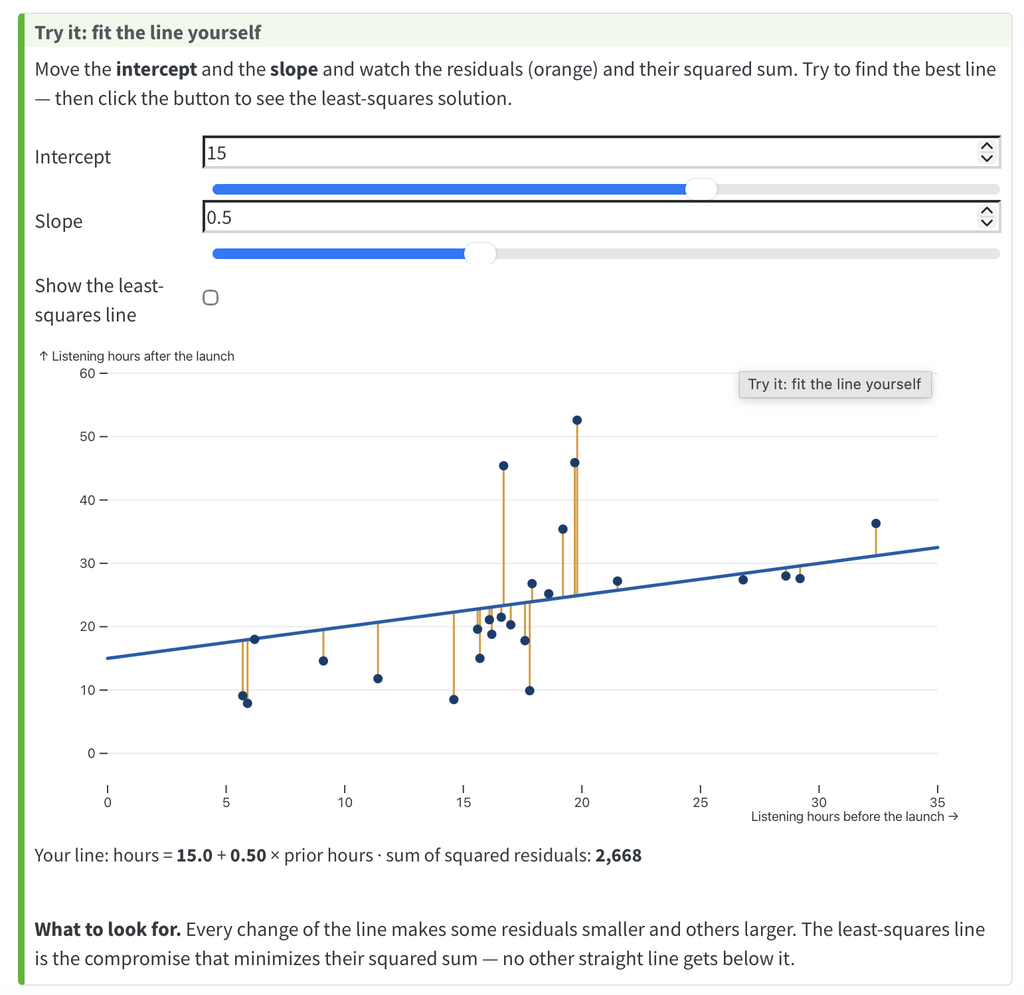

# 5.3 Reading a regression

## The full output

```r
model_naive <- lm(hours ~ smart_mix, data = smartmix_obs)
summary(model_naive)
```

```
Call:
lm(formula = hours ~ smart_mix, data = smartmix_obs)

Residuals:
   Min     1Q Median     3Q    Max
-20.88  -7.64  -2.06   4.76 101.22

Coefficients:
            Estimate Std. Error t value Pr(>|t|)
(Intercept)   17.541      0.300    58.5   <2e-16 ***
smart_mix      9.341      0.525    17.8   <2e-16 ***
---
Signif. codes:  0 '***' 0.001 '**' 0.01 '*' 0.05 '.' 0.1 ' ' 1

Residual standard error: 11 on 1998 degrees of freedom
Multiple R-squared:  0.137, Adjusted R-squared:  0.136
F-statistic:  316 on 1 and 1998 DF,  p-value: <2e-16
```

## Reading the coefficients

**`(Intercept)` = 17.5**: the predicted hours when all predictors are 0 — here the mean of the **non-adopters**.

**`smart_mix` = 9.3**: the change in hours for a **one-unit increase** in the predictor. For a 0/1 variable that is the step from 0 to 1: **adopters − non-adopters**.

**Continuous predictor** (previous section): `prior_hours` = 0.73 → one more hour before the launch goes with **0.73 more hours** after it.

**Several predictors** (next section): every coefficient is read **“holding the other variables constant”**.

The general rule: a coefficient is the change in $y$ when its predictor increases by **one unit** and nothing else changes. Whether that change is *causal* is the question of §5.4.

## Line by line

[output not shown]

With one 0/1 predictor, the regression **is** the comparison of two means — and its *t*-test is the two-sample *t*-test. `confint(model_naive)` gives the confidence intervals.

## R²: the share of explained variation

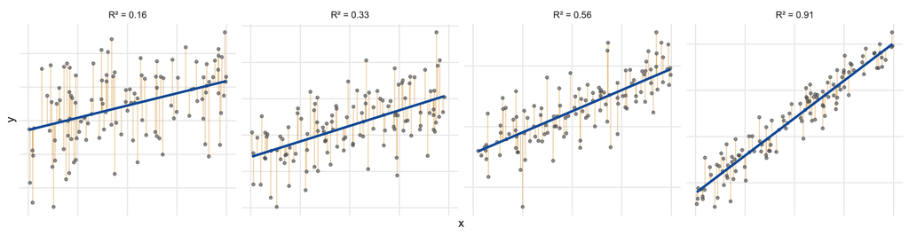

- Same idea as $\eta^2$ in the ANOVA: $R^2 = SS_M / SS_T$ — the share of the variation in $y$ that the line explains
- Smart Mix dummy: 0.14 · prior listening: 0.41

R² says how well the line **fits** — nothing about whether the slope is **causal**, and a small R² does not make an effect unimportant (14% explained, but 9 hours).

# 5.4 Adjusting for confounders

## Holding prior listening constant

```r
model_prior <- lm(hours ~ smart_mix + prior_hours, data = smartmix_obs)
round(coef(summary(model_prior)), 3)
```

```
            Estimate Std. Error t value Pr(>|t|)
(Intercept)    6.451      0.412   15.65        0
smart_mix      4.901      0.443   11.07        0
prior_hours    0.662      0.020   33.17        0
```

The Smart Mix coefficient drops from **9.3** to **4.9**: now the difference between adopters and non-adopters **with the same prior listening**. Part of the naive gap belonged to prior listening — and is now attributed to it.

## More variables, same logic

```r
model_full <- lm(hours ~ smart_mix + prior_hours + tenure + premium + device, data = smartmix_obs)
round(coef(summary(model_full)), 3)
```

```
              Estimate Std. Error t value Pr(>|t|)
(Intercept)      6.255      0.540  11.575    0.000
smart_mix        4.472      0.437  10.223    0.000
prior_hours      0.613      0.021  29.688    0.000
tenure           0.038      0.011   3.344    0.001
premium          2.924      0.426   6.869    0.000
deviceAndroid   -1.475      0.422  -3.493    0.000
deviceDesktop   -2.488      0.576  -4.320    0.000
```

**Reading the table, one line each, “holding the other variables constant”:** `smart_mix` 4.5 = adopters listen 4.5 h more than non-adopters with the same prior listening, tenure, plan and device · `prior_hours` 0.61 = one more hour before the launch goes with 0.61 h more after it · `tenure` 0.04 = each month of tenure, +0.04 h · `premium` 2.9 = Premium users listen 2.9 h more than free users · `deviceAndroid` / `deviceDesktop` = difference to **iOS** (the reference). Tenure, Premium and device change little for Smart Mix: ≈ **4.5 hours**.

## Naive, adjusted — and the truth

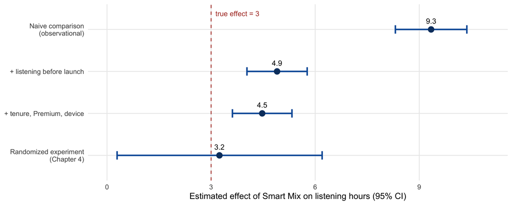

Adjustment removed ~75% of the bias — **not all of it**. We adjusted for a *proxy* of enthusiasm, not for enthusiasm. Regression removes exactly the confounding your variables capture.

## Live demo: how good must a proxy be?

Course book, §5.4 — set the **quality of the proxy** and the **strength of confounding**.

https://wu-rds.github.io/MA2026/05-observational-data.html#sec-obs-adjust

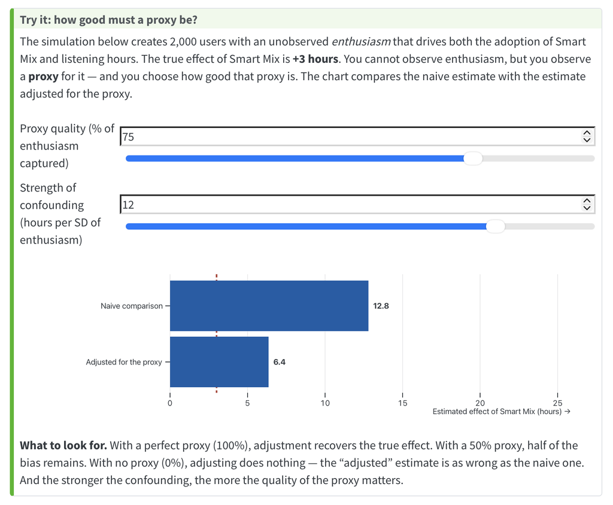

With a 50% proxy, how much of the bias is left? And what happens at 0%?

## Two warnings

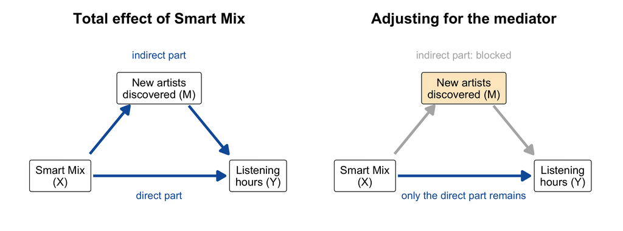

**Adjusting for the wrong variable makes it worse.** A **mediator** lies on the causal path: if Smart Mix works by making users discover new artists, adjusting for `new_artists` **blocks the indirect part** and the coefficient shows only the direct part. Only **confounders** — determined *before* the treatment, affecting treatment *and* outcome — belong in the model.

**“Enough” is untestable.** The assumption of no unobserved confounders cannot be checked in the data. Report *what* you adjusted for — and what you plausibly could not.

## Where the unobserved variable goes

**The true model** (price and sales; weather raises both):

$$\text{Sales}_i = \beta_0 + \beta_1 \, \text{Price}_i + \beta_2 \, \text{Weather}_i + \phi_i$$

**Weather is not in the data** — so we estimate:

$$\text{Sales}_i = \beta_0 + \beta_1 \, \text{Price}_i + \underbrace{\varepsilon_i}_{= \, \beta_2 \text{Weather}_i + \phi_i}$$

- The omitted variable does not disappear — it moves **into the error term**
- Weather also drives price → the error term is **correlated with the regressor**
- OLS attributes the weather effect to price: $\hat{\beta}_1$ is **biased**, and more data do not help

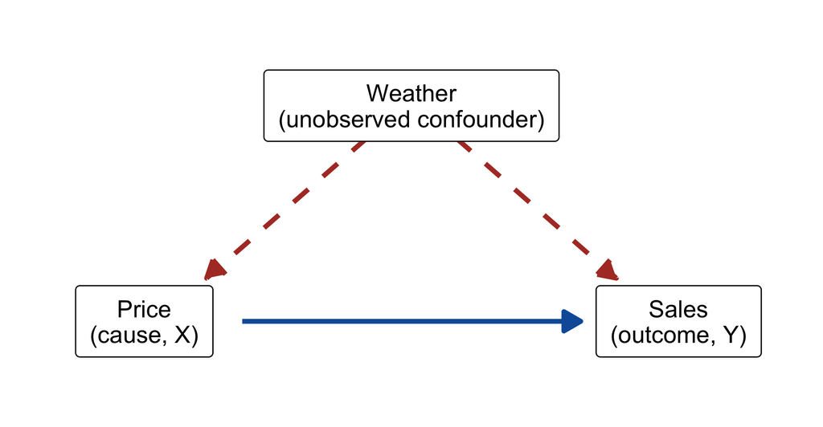

Smart Mix: replace price by **adoption**, weather by **enthusiasm**. Enthusiasm is in $\varepsilon_i$ and drives adoption → 9.3 h instead of 3.

## Variation has two components

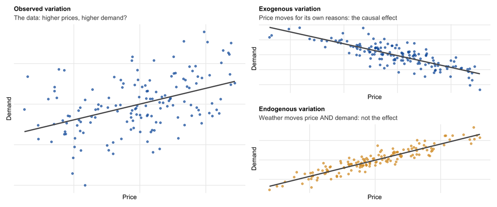

The observed price variation mixes **exogenous** variation (price moves for its own reasons → the causal effect, downward) with **endogenous** variation (weather moves price *and* demand → upward). OLS on the mix gives a slope that is neither. Adjustment and experiments are ways to isolate the exogenous part.

## Exogeneity

$$y_i = \beta_0 + \beta_1 x_i + \varepsilon_i$$

**Exogeneity cannot be tested.** The residuals of a fitted regression are uncorrelated with the predictors *by construction* — the data always “look” exogenous. The argument has to come from outside: theory, and how the data came to be (who chose the treatment, and why).

## Your turn (5 min)

Add **`age`** to the full model. Does the Smart Mix coefficient change? Why (not)?

```r
model_age <- lm(hours ~ smart_mix + prior_hours + tenure + premium + device + age,
                data = smartmix_obs)
round(coef(summary(model_age)), 3)
```

Then: which variable in the data set should you **never** adjust for when estimating the effect of Smart Mix on listening — and why?

# 5.5 Categorical predictors

## Dummies and the reference category

```r
coef(model_full)[c("premium", "deviceAndroid", "deviceDesktop")]
```

```
      premium deviceAndroid deviceDesktop
        2.924        -1.475        -2.488
```

- **0/1 variable** (`premium`): coefficient = difference between the two groups, other variables held constant
- **Several categories** (`device`): R picks a **reference** (first level: iOS) and creates one **dummy** per other category
- Each dummy = difference to the **reference**

Android users: **1.5 hours less** than iOS users; Desktop: **2.5 hours less** — holding everything else constant. *p*-values compare each category with the reference; “does device matter at all?” → `anova(model_without, model_full)` (the ANOVA of Chapter 4).

# 5.6 Prediction vs. explanation

## Predicting listening time for new users

```r
set.seed(42)
train_ids <- sample(nrow(smartmix_obs), 1500)
train <- smartmix_obs[train_ids, ]
test  <- smartmix_obs[-train_ids, ]
model_pred <- lm(hours ~ prior_hours + tenure + premium +
                   device + smart_mix, data = train)
test$predicted <- predict(model_pred, newdata = test)

summary(model_pred)$r.squared        # in-sample R² (training data)
```

```
[1] 0.4817
```

```r
cor(test$predicted, test$hours)^2    # out-of-sample R² (test data)
```

```
[1] 0.4235
```

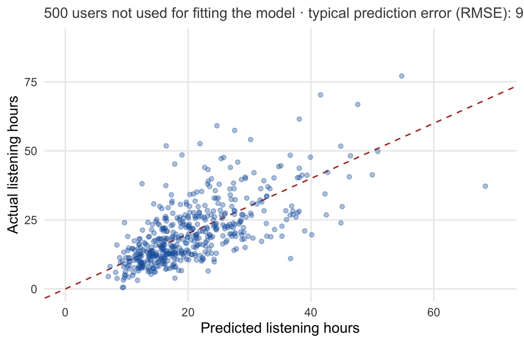

**Fit on the training users, judge on the test users.** The in-sample R² flatters the model (it was fitted to these very users); the **out-of-sample R²** — the squared correlation between predicted and actual values in the test set — is the honest number. Close here (0.48 vs. 0.42): few predictors, many users. With many predictors and small samples, the gap is **overfitting** made visible.

## How far off is a prediction? The RMSE

$$\text{RMSE} = \sqrt{\frac{1}{n} \sum_{i=1}^{n} \left( y_i - \hat{y}_i \right)^2}$$

1. Each test user’s **prediction error** $y_i - \hat{y}_i$
2. **Square** it: over- and under-predictions do not cancel, big misses count more
3. **Average** the squares
4. **Root**: back to the original unit (hours)

```r
sqrt(mean((test$hours - test$predicted)^2))
```

```
[1] 9.425
```

## Two questions, two rules

**Explanation** (causal question): include confounders, exclude mediators, state what is unobserved. The **coefficient** matters; R² is secondary.

**Prediction**: include whatever predicts; judge by **out-of-sample errors**. Coefficients are not interpreted; the **predictions** matter.

A model can be a **good predictor and a bad explainer** at the same time. Where in your company would each mistake — reading causal effects off a prediction model, or judging a causal model by its R² — cost money?

## Coding block: two cases (40 min)

**Case 1: podcast promotion** — `podcast_promo.csv`, 400 episodes: promotion spend, host followers, downloads.

1. Scatter plot of downloads against spend; the **correlation**; one sentence
2. `lm()` + `summary()`: interpret the **slope**; read off **R²**
3. Is the slope **causal**? What would you need to argue?

**Laptops open — alone or with your neighbor.** Section “Coding block” in `05-observational-data.R`.

**Case 2: a loyalty program** — `loyalty_program.csv`, 1,500 customers, membership is **opt-in**.

1. **Naive:** `spending ~ member` — interpret; why not causal?
2. **Adjust** for `spend_prev`, `tenure`, `device`: how does the coefficient change, what does it mean now? With 95% CI
3. Interpret the coefficient of `device`
4. Is membership **exogenous** after adjustment? Argue from the data-generating process

At the end: one table presents case 1, another table case 2 — Menti first: enter your slope (case 1) and your adjusted coefficient (case 2).

## Learning check (Part I)

1. Slope of hours on prior hours = 0.73. Interpret — and why is it not causal?
2. Adding a variable can increase, decrease, or leave the Smart Mix coefficient unchanged. When does each happen?
3. `planFamily` = 4.2 with reference “Free”. Interpret. How do you test whether the plan matters at all?
4. R² = 0.71 for predicting next month’s spending with 25 predictors on 300 customers. What do you ask?

## Next session

**Observational data II** — beyond the straight line, and a quasi-experiment

- Functional form: when a line is wrong — **elasticities**
- Yes/no outcomes: logistic regression
- The three diagnostics that change decisions
- **Difference-in-differences** with real playlist data

Before next session: work through §5.1–5.6 on the course site. **Debrief of Assignment 2** at the start of the session.

# Part 2 · Observational data II

## Before we start

**Debrief A2 + quiz Chapter 5, Part I** *(15 min, one sheet)*

- Page 1: debrief of **Assignment 2** (3 assignment points)
- Page 2: quiz on **Chapter 5, §5.1–5.6** (participation)
- Closed book, no laptop

**Assignment 3** is handed out today (end of session).

**Devices only when we code** — as last time

Today: functional form and elasticities → logistic regression → diagnostics → difference-in-differences → **one coding block with two cases** → A3.

# 5.7 Functional form: when the line is wrong

## Two assumptions of the linear model

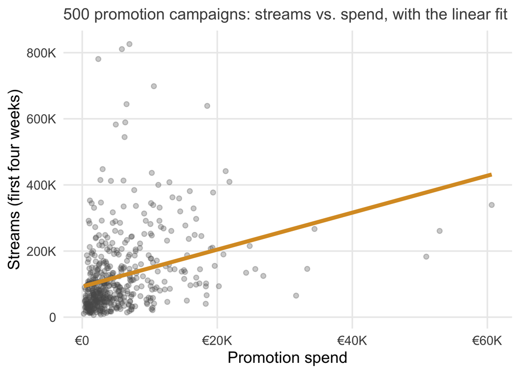

**The case.** A label runs **500 promotion campaigns** for new releases; for each we know the **spend** (euros), the artist’s followers, the playlist placements, the genre — and the **streams in the first four weeks**. The chart: streams against spend, one dot per campaign, with the linear regression line.

$$y_i = \beta_0 + \beta_1 x_{1i} + \beta_2 x_{2i} + \dots + \varepsilon_i$$

**Linearity:** a one-unit change in $x$ has the same effect at every level of $x$ — **constant marginal returns**: 10 → 11 € adds as many streams as 100,000 → 100,001 €. **Additivity:** the effect of one predictor does not depend on the others.

**Relaxed where:** linearity → the **multiplicative (log-log) model** (this section) · additivity → the multiplicative model and **interactions** (Chapter 6) · **detecting** a wrong form → the residual plot (§5.9)

## Two models for the same data

$$\text{streams}_i = \beta_0 + \beta_1 \, \text{spend}_i + \varepsilon_i$$

$$\text{streams}_i = \beta_0 \cdot \text{spend}_i^{\,\beta_1} \cdot \varepsilon_i$$

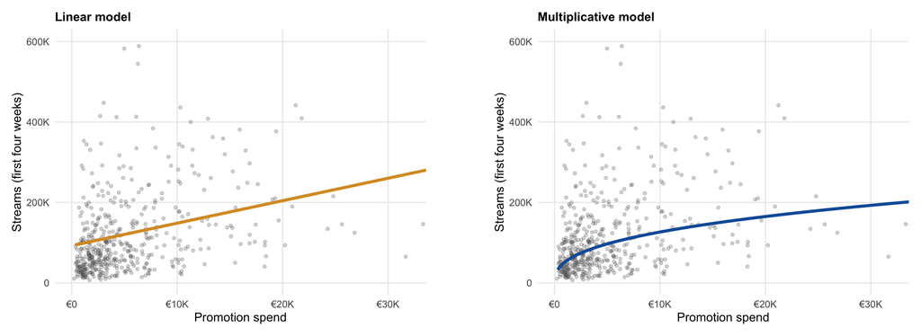

**Left:** the linear model — a straight line. **Right:** the **multiplicative** model — spend enters as a *power*, and the fitted curve bends: the first euros buy many streams, later euros fewer. Same data, same question, a different assumption about *how* spend works.

## Marginal returns: what one more step buys

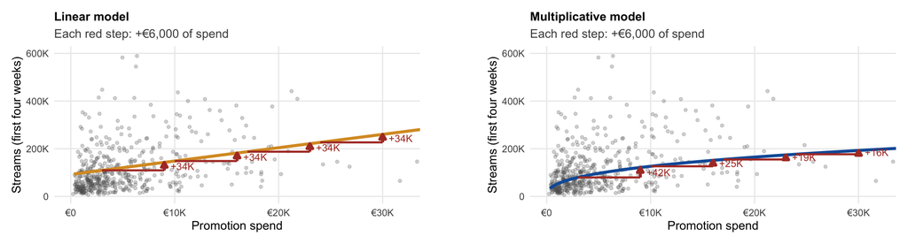

## Estimating the multiplicative model: take logs

**Multiplicative:** each predictor *scales* the outcome

$$\text{streams}_i = e^{\beta_0} \cdot \text{spend}_i^{\,\beta_1} \cdot \text{followers}_i^{\,\beta_2} \cdot e^{\varepsilon_i}$$

**Take logs on both sides** → additive again, a job for `lm()`:

$$\log(\text{streams}_i) = \beta_0 + \beta_1 \log(\text{spend}_i) + \beta_2 \log(\text{followers}_i) + \varepsilon_i$$

**Three log rules do the work:**

- $\log(a \cdot b) = \log a + \log b$ — a product becomes a sum
- $\log(a^b) = b \log a$ — a power becomes a factor
- $\log(e^x) = x$

**Additive model:** each euro adds $\beta_1$ streams, always.  
**Multiplicative model:** each euro adds a **percentage** of the current streams — diminishing returns built in; and the effect of spend is *scaled* by the followers.

## The same curve on log-scaled axes

$$\text{streams}_i = \beta_0 \cdot \text{spend}_i^{\,\beta_1} \cdot \varepsilon_i$$

$$\log(\text{streams}_i) = \log \beta_0 + \beta_1 \log(\text{spend}_i) + \log \varepsilon_i$$

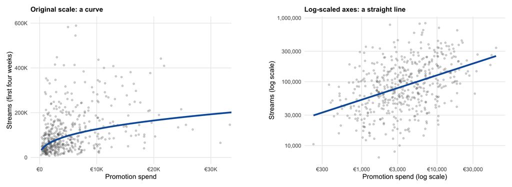

## Both models in R: the full output

$\text{streams}_i = \beta_0 + \beta_1 \, \text{spend}_i + \varepsilon_i$

```r
model_lin_simple <- lm(streams ~ spend, data = campaigns)
summary(model_lin_simple)
```

```
Call:
lm(formula = streams ~ spend, data = campaigns)

Residuals:
    Min      1Q  Median      3Q     Max
-204459  -67186  -34157   27654  694356

Coefficients:
             Estimate Std. Error t value Pr(>|t|)
(Intercept) 92600.025   6782.260   13.65   <2e-16 ***
spend           5.589      0.781    7.16    3e-12 ***
---
Signif. codes:  0 '***' 0.001 '**' 0.01 '*' 0.05 '.' 0.1 ' ' 1

Residual standard error: 114000 on 498 degrees of freedom
Multiple R-squared:  0.0932,    Adjusted R-squared:  0.0914
F-statistic: 51.2 on 1 and 498 DF,  p-value: 3.01e-12
```

$\log(\text{streams}_i) = \beta_0 + \beta_1 \log(\text{spend}_i) + \varepsilon_i$

```r
model_loglog_simple <- lm(log(streams) ~ log(spend), data = campaigns)
summary(model_loglog_simple)
```

```
Call:
lm(formula = log(streams) ~ log(spend), data = campaigns)

Residuals:
    Min      1Q  Median      3Q     Max
-2.2804 -0.5076  0.0152  0.5652  2.3720

Coefficients:
            Estimate Std. Error t value Pr(>|t|)
(Intercept)   8.2098     0.3094    26.5   <2e-16 ***
log(spend)    0.3841     0.0375    10.2   <2e-16 ***
---
Signif. codes:  0 '***' 0.001 '**' 0.01 '*' 0.05 '.' 0.1 ' ' 1

Residual standard error: 0.802 on 498 degrees of freedom
Multiple R-squared:  0.174, Adjusted R-squared:  0.173
F-statistic:  105 on 1 and 498 DF,  p-value: <2e-16
```

**Reading:** one more euro → **+5.6 streams**, at every budget; intercept 92,600 = predicted streams at zero spend.

**Reading:** +1% spend → **+0.38% streams** (elasticity), at every budget. **R² 0.17 vs. 0.09:** the log-log model explains more of the variation — a first hint that its shape fits the data better (the residual plots in §5.9 confirm it).

## Why the log transformation straightens the curve

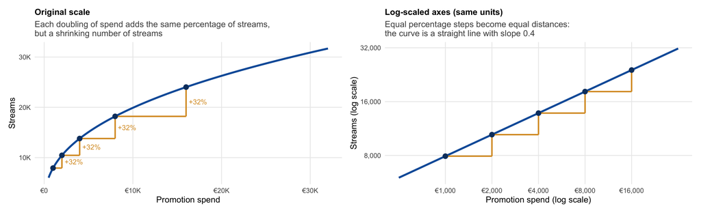

Multiplicative model: equal **percentage** steps in $x$ → equal **percentage** steps in $y$ (each doubling of spend adds the same percentage of streams, but ever fewer streams). The logarithm turns percentages into distances — a doubling is always $\log 2$ — so the curve becomes a line with slope = elasticity.

## Elasticity: linear vs. log-log model

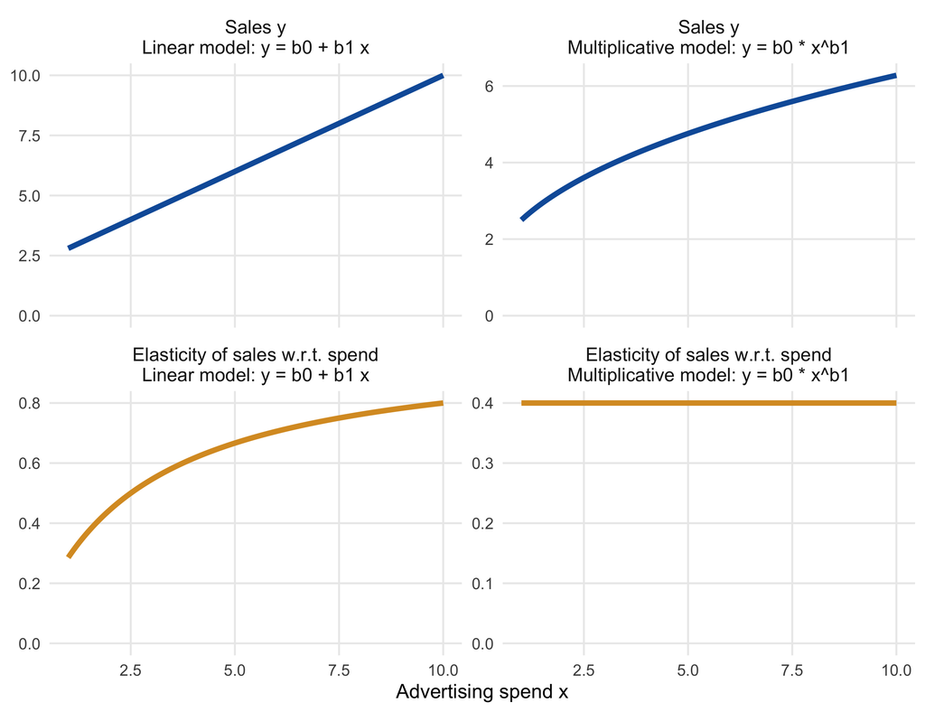

Elasticity $\eta_x = (\Delta y / y) / (\Delta x / x)$: the % change in $y$ per % change in $x$

- **Linear:** $\eta_x = \beta_1 \, x / y$ **rises** with $x$ — advertising gets *relatively more* effective the more you spend: implausible
- **Multiplicative:** $\eta_x = \beta_1$ **constant**; the marginal returns fall

Additive in **logs** = multiplicative in **levels**: the same *percentage* effect for every artist; the *number* of streams it buys scales with the follower base.

After Hanssens, Parsons & Schultz (2001), Market Response Models.

## What the elasticity says about the shape

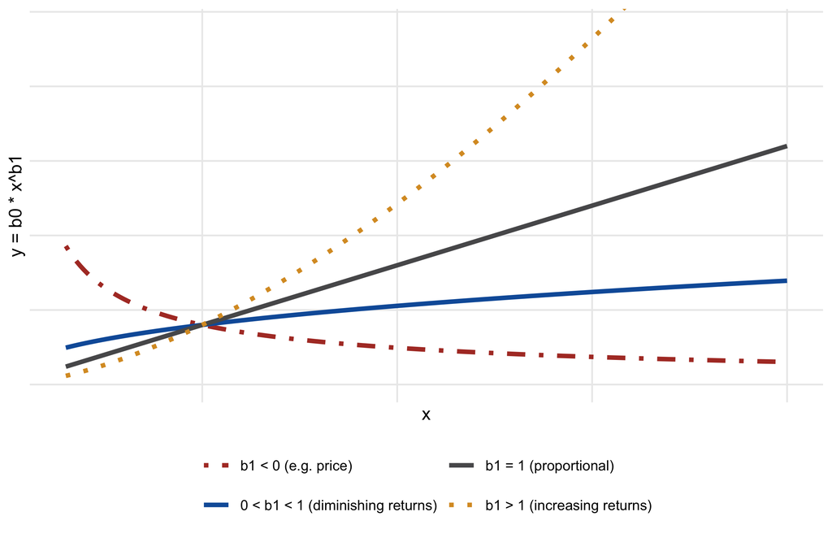

- $\beta_1 < 0$: falls, flattening out — **price**
- $0 < \beta_1 < 1$: **diminishing returns** — advertising, promotion; most marketing elasticities (< 0.5)
- $\beta_1 = 1$: **proportional** — a line through the origin; the one linear case
- $\beta_1 > 1$: **increasing returns** — each extra euro buys *more* than the last. Rare: **network effects** (a messaging app or marketplace gains value with every user), or a promotion that crosses a **threshold** and spreads by word of mouth

Not defined at $x$ = 0; no minimum level of $y$. Optimum: zero or infinity in the linear model, finite in the multiplicative one.

## The full log-log model: an elasticity per input

```r
model_loglog <- lm(log(streams) ~ log(spend) + log(followers) + placements + genre, data = campaigns)
summary(model_loglog)
```

```
Call:
lm(formula = log(streams) ~ log(spend) + log(followers) + placements +
    genre, data = campaigns)

Residuals:
    Min      1Q  Median      3Q     Max
-1.5962 -0.2684  0.0284  0.3030  1.4799

Coefficients:
                   Estimate Std. Error t value Pr(>|t|)
(Intercept)          2.8815     0.2346   12.28  < 2e-16 ***
log(spend)           0.3310     0.0207   16.00  < 2e-16 ***
log(followers)       0.5071     0.0157   32.28  < 2e-16 ***
placements           0.1203     0.0119   10.07  < 2e-16 ***
genreHipHop/Rap      0.1994     0.0476    4.19 0.000033 ***
genreRock           -0.2555     0.0599   -4.27 0.000023 ***
genreElectro/Dance   0.1026     0.0594    1.73    0.085 .
---
Signif. codes:  0 '***' 0.001 '**' 0.01 '*' 0.05 '.' 0.1 ' ' 1

Residual standard error: 0.44 on 493 degrees of freedom
Multiple R-squared:  0.754, Adjusted R-squared:  0.751
F-statistic:  251 on 6 and 493 DF,  p-value: <2e-16
```

`log(spend)` = **0.33**: +1% spend → +0.33% streams, at every budget. Elasticities have no units and are **comparable**: followers (0.51) matter more than the budget. `placements` = 0.12: a semi-elasticity, +12% per placement.

A **marketing mix model** in miniature: an **elasticity per channel** → shift budget to where a euro buys the largest percentage gain. Real MMMs add carryover and saturation — and spend is **endogenous**, so companies calibrate them with experiments.

## Four ways to combine levels and logs

| Model | Equation | Reading $\beta_1$ | Typical use |
| --- | --- | --- | --- |
| **Level-level** | $y = \beta_0 + \beta_1 x$ | +1 unit $x$ → $\beta_1$ units of $y$ | Constant effects; dummies |
| **Log-level** | $\log y = \beta_0 + \beta_1 x$ | +1 unit $x$ → ≈ $100\beta_1$% of $y$ (exact: $100(e^{\beta_1}-1)$%): **semi-elasticity** | A placement adds 12% |
| **Level-log** | $y = \beta_0 + \beta_1 \log x$ | +1% $x$ → ≈ $\beta_1/100$ units of $y$ | Diminishing returns, outcome in units |
| **Log-log** | $\log y = \beta_0 + \beta_1 \log x$ | +1% $x$ → $\beta_1$% of $y$: **elasticity** | Spend, price: the marketing default |

The transformation decides the **unit of the coefficient**: units, percent, or percent per percent. In our model, `log(spend)` and `log(followers)` are elasticities; `placements` and the genre dummies are semi-elasticities (percent per unit).

## Your turn (5 min)

From the log-log model:

1. `genreHipHop/Rap` = 0.20. By what percentage do HipHop/Rap campaigns differ from Pop campaigns (the reference) — approximately and exactly?
2. A marketing manager proposes to raise the promotion budget of every campaign by **10%**. By what percentage would streams increase, according to the model? Is this a causal claim?

## Live demo: linear or log-log?

Course book, §5.7 — move the **true elasticity**.

https://wu-rds.github.io/MA2026/05-observational-data.html#sec-obs-form

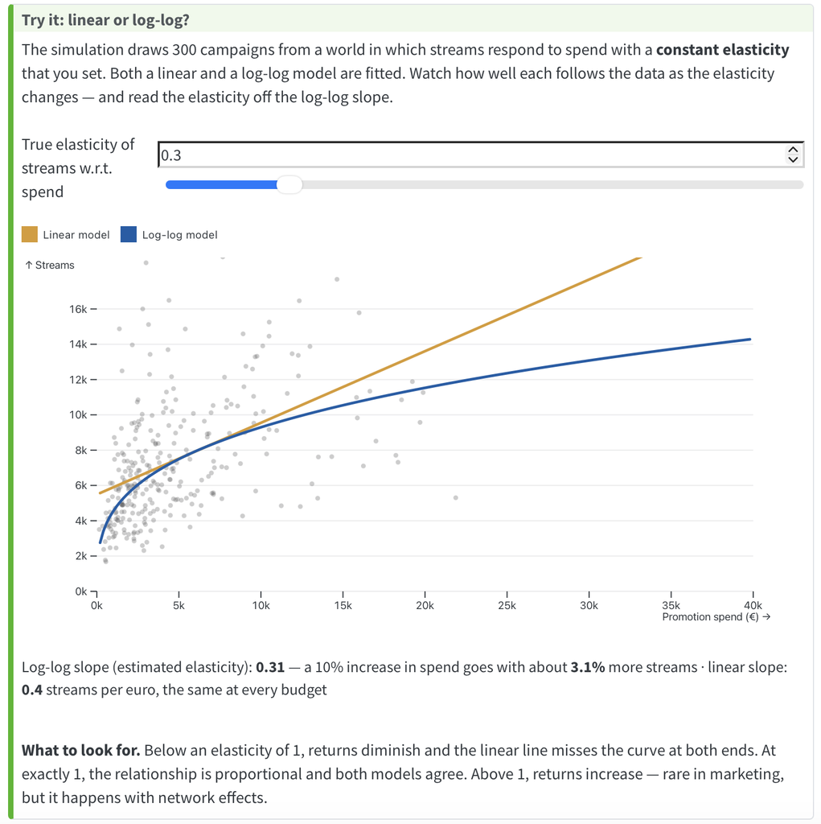

Elasticity **< 1**: diminishing returns, the line misses at both ends. **= 1**: proportional. **> 1**: increasing returns (rare — network effects).

# 5.8 Yes/no outcomes: logistic regression

## The case: who upgrades to Premium?

**Same data as before — the Smart Mix launch — a new question.** Among the **free users** (1,239 of the 2,000), the service recorded whether a user **upgraded to Premium** within three months after the launch.

- Outcome: `upgraded` — **1** if the user upgraded, **0** if not; 22% did
- Question of the growth team: *does listening time predict who upgrades — and how strongly?*
- The answer feeds a **targeting** decision: which free users should get the upgrade offer first?

A **yes/no outcome**. Everything so far modeled a *number* (hours, streams). Now the outcome is a **probability** — and a probability has to stay between 0 and 1.

What goes wrong if we just run `lm(upgraded ~ hours)`?

## Why not a straight line?

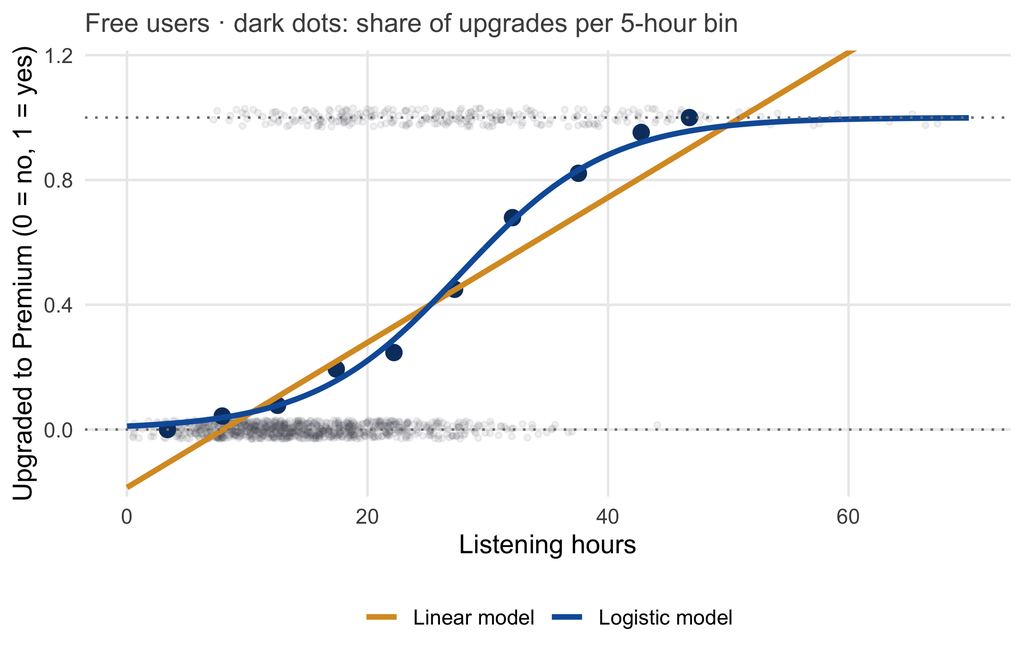

- Outcome: **upgraded to Premium** within 3 months — free users, 22% did
- A line predicts probabilities **below 0** and **above 1** — and misses the shape
- The share of upgrades rises slowly, then steeply, then flattens near 100%: an **S-curve**

We need a function that only takes values between 0 and 1.

## The logistic function

$$P(y_i = 1) = \frac{1}{1 + e^{-(\beta_0 + \beta_1 x_i)}}$$

- $\beta_0 + \beta_1 x_i$ is the familiar line — fed through a function that squeezes it into [0, 1]: line far **below** 0 → $P \approx 0$ · line = 0 → $P$ = 0.5 · line far **above** 0 → $P \approx 1$
- Derived from the **log-odds**: odds = $P / (1 - P)$ (“1 to 4” = 0.25)

$$\log\left(\frac{P(y_i = 1)}{1 - P(y_i = 1)}\right) = \beta_0 + \beta_1 x_i$$

- Exponentiate → the odds: $\dfrac{P(y_i = 1)}{1 - P(y_i = 1)} = e^{\beta_0 + \beta_1 x_i}$

```r
free_users <- filter(smartmix_obs, premium == 0)
model_upgrade <- glm(upgraded ~ hours, family = binomial,
                     data = free_users)
round(coef(summary(model_upgrade)), 3)
```

```
            Estimate Std. Error z value Pr(>|z|)
(Intercept)   -4.517      0.244  -18.53        0
hours          0.163      0.011   15.05        0
```

`glm()` = *generalized* linear model: the same predictors, a different link to the outcome. Estimated by **maximum likelihood**, not least squares (no line, no residuals to square): the coefficients under which the observed 0/1 data are most likely.

## Weak vs. strong effects: the slope

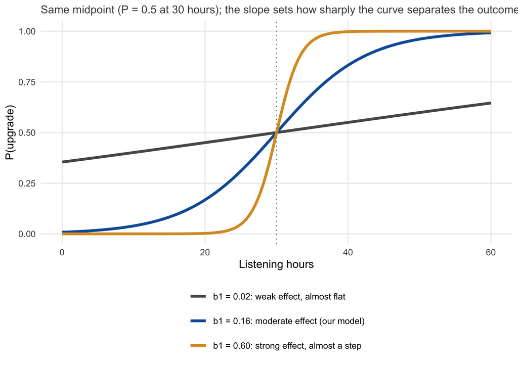

- $\beta_1$ **≈ 0**: almost flat — the predictor hardly **discriminates** between upgraders and non-upgraders
- $\beta_1$ **large**: an almost vertical step — listening time nearly determines who upgrades
- $\beta_0$ shifts the curve; **midpoint** ($P$ = 0.5) at $x = -\beta_0 / \beta_1$ ≈ **28 hours**

**Sign** = direction, **size** = how sharply the outcome responds — on the log-odds scale; “how much” in probabilities: next two slides.

## Reading the coefficients: odds ratios

```r
exp(coef(model_upgrade))
```

```
(Intercept)       hours
    0.01093     1.17689
```

```r
exp(confint(model_upgrade))
```

```
               2.5 %  97.5 %
(Intercept) 0.006661 0.01734
hours       1.152949 1.20296
```

- Coefficient 0.163 = change in the **log-odds** per hour — no intuition
- $e^{0.163}$ = **1.18**: each hour multiplies the **odds** of an upgrade by 1.18 (+18%) — the same factor everywhere
- Read **sign** and **significance** directly from the output

**Odds ratio ≠ probability ratio.** “Odds +18%” is not “18% more likely” — unless the event is rare. For managers, translate into **probabilities**.

## Reading the coefficients: probabilities at x and x + 1

```r
predict(model_upgrade, type = "response",
        newdata = data.frame(hours = c(10, 11, 20, 21, 30, 31, 40, 41)))
```

```
      1       2       3       4       5       6       7       8
0.05275 0.06151 0.22111 0.25043 0.59135 0.63005 0.88062 0.89671
```

- 10 → 11 hours: **+0.9** points · 20 → 21: **+2.9** · 30 → 31: **+3.9** · 40 → 41: **+1.6**
- Same coefficient, same odds ratio — a **different change in probability**, largest around 50%

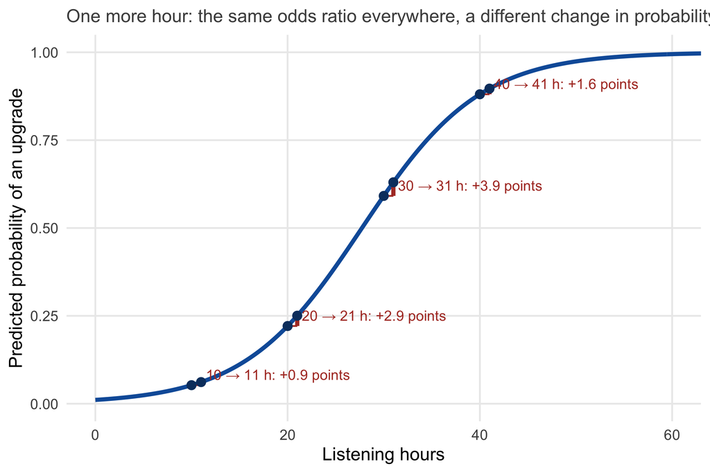

Report effects as **predicted probabilities at chosen values** (10 vs. 30 hours: 5% vs. 59%) or as the **average change** across all users — “the effect of one more hour” has no single answer in percentage points.

## A second case: who cancels?

**Churn.** For all 2,000 users, the data record whether the user **cancelled** the service within three months after the launch: `churn` = 1 (17% did), 0 otherwise.

- Question of the retention team: *which users are at risk — and does Premium status protect against churn, once listening and tenure are taken into account?*
- Candidates: `hours`, `premium`, `tenure`, `smart_mix` — the same predictors as in the adjustment models, now for a yes/no outcome
- The answer feeds a **retention** decision: whom to contact before they leave

Logistic regression with **several predictors**: the same logic as multiple regression — each coefficient holds the others constant — but on the **log-odds** scale.

## Several predictors: churn

```r
model_churn <- glm(churn ~ hours + premium + tenure + smart_mix, family = binomial, data = smartmix_obs)
round(coef(summary(model_churn)), 3)
```

```
            Estimate Std. Error z value Pr(>|z|)
(Intercept)    0.277      0.161   1.717    0.086
hours         -0.061      0.009  -7.130    0.000
premium       -0.533      0.153  -3.489    0.000
tenure        -0.020      0.004  -5.452    0.000
smart_mix     -0.256      0.162  -1.579    0.114
```

```r
p_free    <- predict(model_churn, newdata = mutate(smartmix_obs, premium = 0), type = "response")
p_premium <- predict(model_churn, newdata = mutate(smartmix_obs, premium = 1), type = "response")
mean(p_premium - p_free)
```

```
[1] -0.06477
```

# 5.9 The diagnostics that change decisions

## Three checks worth doing every time

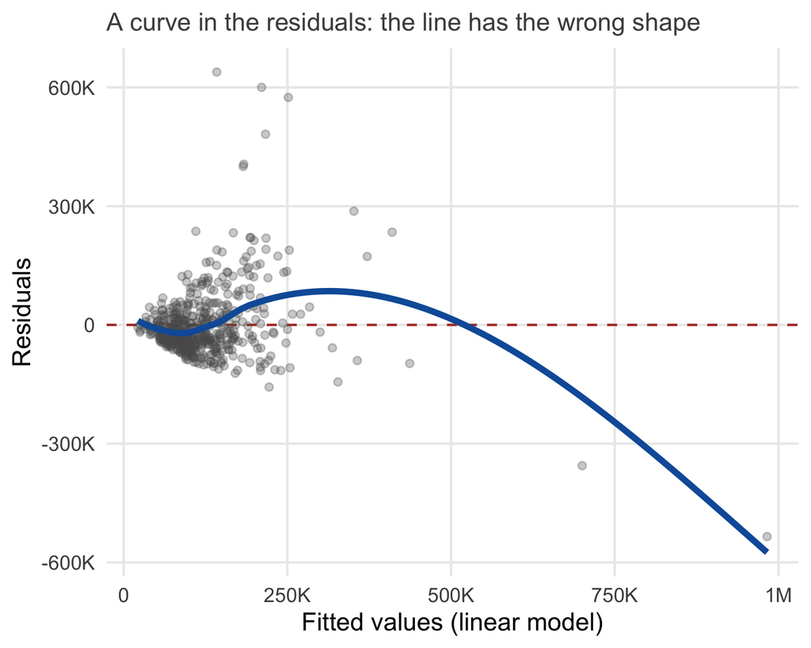

**1. Is the line the right shape?** Curved residuals → change the functional form (log) or add a predictor.

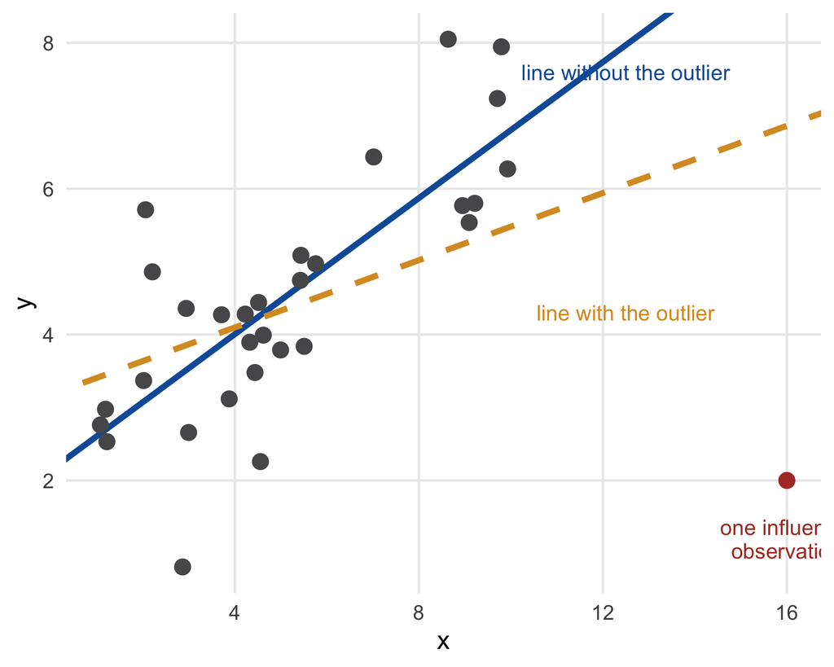

**2. Does one observation drive the result?** `plot(model, which = 5)`; refit without it — if the conclusion changes, say so.

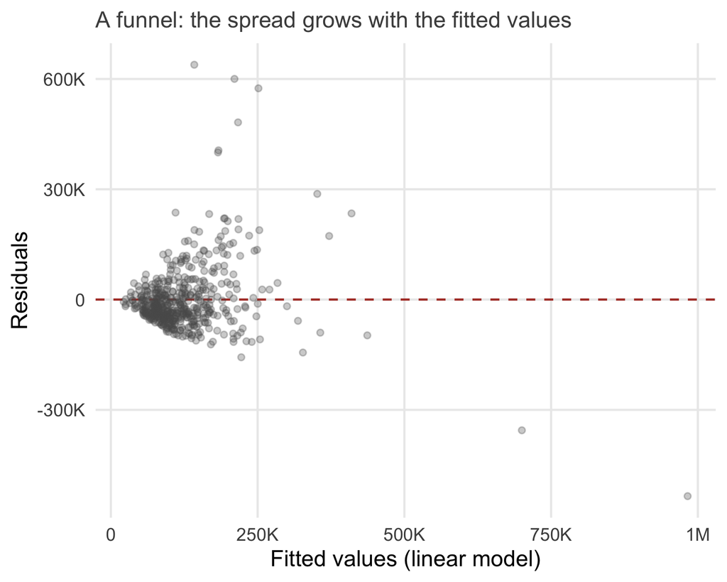

**3. Is the uncertainty right?** A funnel (test: `bptest(model)`) → **robust standard errors**: `coeftest(model, vcov = vcovHC(model))`.

# 5.10 A quasi-experiment: difference-in-differences

## The case: what is a playlist listing worth?

**Real data from a WU research project.** Labels pay a lot of attention to **editorial playlists**: being listed on a major playlist is supposed to boost a song’s streams. But by how much?

- **290 songs**, weekly streams over **21 weeks** (January to June 2018)
- On **March 19, 2018**, 53 of them were added to a major playlist (the **treated** songs); the other 237 were not (the **control** songs)
- Question: *how much did the listing increase the treated songs’ streams?*

**No randomization:** the curators chose the songs — and they pick songs that are already doing well. A before/after comparison of the treated songs alone would mix the listing effect with the general trend; a treated/control comparison would mix it with the curators’ selection.

What do we need to isolate the effect of the listing?

## Playlist listings as a natural experiment

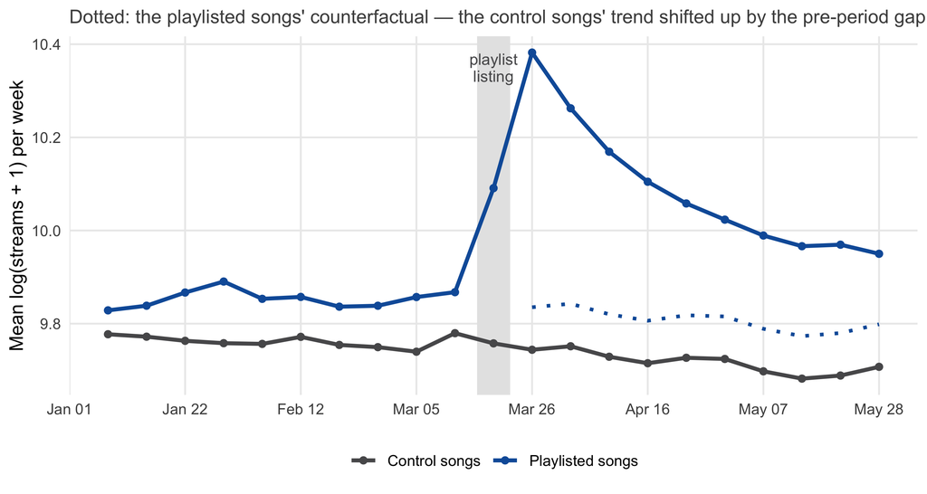

- **Real data:** 290 songs × 21 weeks
- March 19, 2018: **53 songs** added to a major playlist; 237 control songs
- Treated songs start **higher** → levels not comparable
- Before the listing: both groups move in **parallel**
- At the listing: the treated group **jumps**

Data: WU-RDS research project (github.com/WU-RDS/did).

## Two differences, one estimate

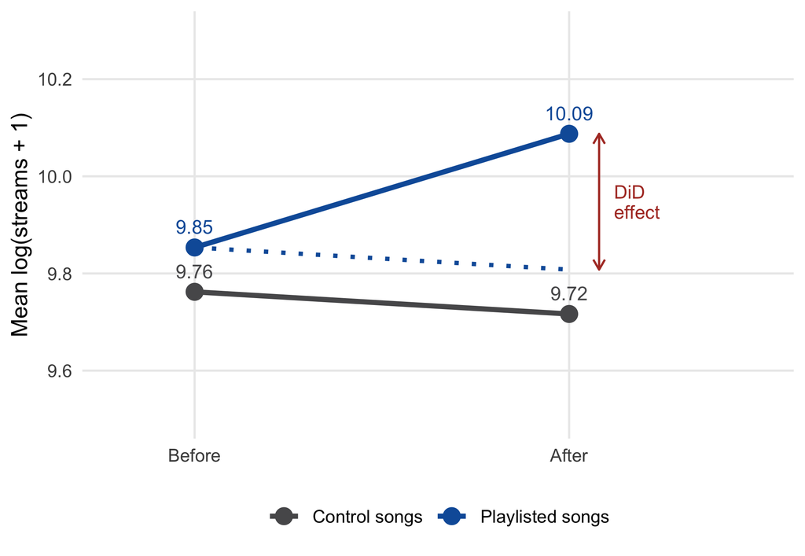

$$\text{DiD} = (\bar{y}_{T,\text{after}} - \bar{y}_{T,\text{before}}) - (\bar{y}_{C,\text{after}} - \bar{y}_{C,\text{before}})$$

(10.09 − 9.85) − (9.72 − 9.76) = **0.28** log points

The control group’s change estimates what would have happened to the treated songs **without** the listing — the counterfactual (dotted).

## The DiD regression: the model

$$\log(\text{streams}_{it}) = \beta_0 + \beta_1 \, \text{treated}_i + \beta_2 \, \text{post}_t + \beta_3 \, (\text{treated}_i \times \text{post}_t) + \varepsilon_{it}$$

$i$ = song, $t$ = week. What the model predicts for the four cells:

|  | **Before** (post = 0) | **After** (post = 1) | After − before |
| --- | --- | --- | --- |
| **Control** (treated = 0) | $\beta_0$ | $\beta_0 + \beta_2$ | $\beta_2$ — the common time trend |
| **Treated** (treated = 1) | $\beta_0 + \beta_1$ | $\beta_0 + \beta_1 + \beta_2 + \beta_3$ | $\beta_2 + \beta_3$ |
| Treated − control | $\beta_1$ — the level difference | $\beta_1 + \beta_3$ | $\beta_3$ — **the DiD effect** |

$\beta_3$ is the difference of the two differences: the change of the treated songs **minus** the change of the control songs. In R, `treated * post` expands to the three terms.

## The DiD regression: the estimate

```r
did_data <- playlist |>
  filter(week != as.Date("2018-03-19")) |>          # drop the listing week
  mutate(log_streams = log(streams + 1))
model_did <- lm(log_streams ~ treated * post, data = did_data)
round(coef(summary(model_did)), 3)
```

```
             Estimate Std. Error t value Pr(>|t|)
(Intercept)     9.762      0.018 545.865    0.000
treated         0.091      0.042   2.182    0.029
post           -0.046      0.025  -1.803    0.071
treated:post    0.280      0.059   4.727    0.000
```

| Coefficient | Meaning |
| --- | --- |
| `(Intercept)` 9.76 | Control, before: baseline |
| `treated` 0.09 | Treated, before: the **level difference** |
| `post` −0.05 | Control, after − before: the **common time trend** |
| `treated:post` **0.28** | The extra change of the treated songs: the **DiD effect** → ≈ **+32% streams** |

## The assumption: parallel trends

```r
placebo_data <- did_data |>
  filter(post == 0) |>
  mutate(fake_post = ifelse(week >= as.Date("2018-02-12"), 1, 0))
round(coef(summary(lm(log_streams ~ treated * fake_post,
                      data = placebo_data)))["treated:fake_post", ], 3)
```

```
  Estimate Std. Error    t value   Pr(>|t|)
     0.002      0.085      0.027      0.978
```

Without the listing, the treated songs would have followed the **same trend** as the controls. **Untestable** — but the pre-period makes it plausible: a fake listing in the pre-period shows **no effect**.

Live demo: course book, §5.10

https://wu-rds.github.io/MA2026/05-observational-data.html#sec-obs-did

## Your turn (5 min)

Add `major_label` as a control variable to the DiD regression:

```r
summary(lm(log_streams ~ treated * post + major_label, data = did_data))
```

Does the effect change? Then: name one situation in which the parallel-trends assumption would **fail** for playlist listings.

## Coding block: two cases (40 min)

**Case 3: podcast promotion, revisited** — `podcast_promo.csv` again.

1. Scatter plot with **both axes logged**: what has changed?
2. **Log-log model** on spend and host followers; interpret both **elasticities**: what does +10% spend do?
3. Compare **R²** with the linear model; which model for the budget advice?

**Laptops open — alone or with your neighbor.** Section “Coding block” in `05-observational-data.R`.

**Case 4: winning back users** — `app_reinstall.csv`, 1,200 users, **randomized** discount 0–60%, reinstalled (1/0), prior sessions.

1. **Share of reinstalls per discount level**, plotted: describe the shape
2. **Logistic regression** of `reinstalled` on `discount` and `prior_use`: sign and **odds ratio** of the discount
3. Predicted probabilities for 10 prior sessions at **10, 11, 40, 41%**: points per extra point of discount — why do the two answers differ?

At the end: one table presents case 3, another case 4 — Menti first: your spend elasticity (case 3) and your odds ratio (case 4).

# What observational data can and cannot tell you

## Two strategies, one honest report

- **Adjustment** handles confounders you can **measure** — only as good as your proxies; “enough” is untestable
- **Difference-in-differences** handles confounders **constant over time** — needs parallel trends, plausible but never proven
- **Prediction** needs no causal assumptions — a good predictor is valuable even if no coefficient is an effect

Report effect + uncertainty + **assumptions**: “Adjusting for prior listening, tenure, Premium and device, adopters listen ≈ 4.5 hours more (95% CI 3.6–5.3), assuming no further differences affect listening — the experiment (3.2) suggests this is not fully met.”

## Assignment 3: analyzing observational data

- Your **personal** data (based on your student ID): an opt-in feature, promotion campaigns, and a small panel with a listing
- Tasks: naive vs. adjusted · categorical predictor · elasticity · logistic regression · DiD
- **Deadline:** Group A Sun, Nov 22 · Group B Wed, Nov 25
- **Debrief** at the start of the following session

**10 points:** report 7 + debrief 3. State your **assumptions** — the best answers say what the data *cannot* show.

## Learning check (Part II)

1. Log-log coefficient of ad spend = 0.15. Interpret. The level model says 0.8 sales per euro — why might the two disagree about a large budget increase?
2. Log-level model, dummy “promotion week” = 0.35. Percentage difference in sales — approximate and exact?
3. Residual plot shows a funnel. Consequence for coefficients, for *p*-values — and the simplest fix?
4. A DiD of a price promotion in treated stores: which assumption, and how can the pre-period help?

## Next session

**Module 6 · Mechanisms & heterogeneity** — *Why, and for whom, does it work?*

- Interaction effects: when the effect differs between groups (moderation)
- Mediation: through which mechanism an effect works
- In experiments and observational data — and in your group project